# Data Analysis for Study 3

# Study 3 Introduction

This Markdown documents the process to analyze the data for Study 3 which looked at the difference between those who received and those who did not receive a warning at the beginning of the study.

Data was collected on July 19, 2018 by using Amazon’s Mechanical Turk for ditribution and Qualtrics as a survey platform.

This HTML was last knitted on: 2019-09-08 17:06:30

## Set Up

### Packages and Libraries

You must run this section before you can run any other chunks.

### Exclusions

You can exclude subjects who did not get the correct answer in the exercise by changing Exclude_Exercise_Check (line 97) to TRUE. The next time you run all the code, these participants will be excluded.

For this report, **no** participants are being excluded from analysis.

## Methods

### Participants

| dem_gender | n |
| --- | --- |
| female | 49 |
| male | 69 |
| other | 1 |

| mean_age | sd_age | median_age | min_age | max_age | range_age |
| --- | --- | --- | --- | --- | --- |
| 32.26891 | 7.812091 | 30 | 21 | 71 | 50 |

We recruited 119 Mturk workers (49 women, 1 non-binary gender; M<sub>age</sub> = 32.27 years, SD<sub>age</sub> = 7.81) participated in Study 3. All participants reported the United States as their location and had a previous task approval rate that was equal to or exceeded 85%.

| dem_ed | n | percentage |
| --- | --- | --- |
| 2 | 11 | 9.2436975 |
| 3 | 24 | 20.1680672 |
| 4 | 1 | 0.8403361 |
| 5 | 9 | 7.5630252 |
| 6 | 58 | 48.7394958 |
| 7 | 3 | 2.5210084 |
| 8 | 13 | 10.9243697 |

70% of participants reported having at least Bachelor’s degree. The samples also exhibited a range of graph literacy.

| n | mean | sd | median | min | max | range | alpha |
| --- | --- | --- | --- | --- | --- | --- | --- |
| 119 | 43.82353 | 8.339865 | 45 | 20 | 60 | 40 | 0.88 |

### Exercise Check

10 did not get the manipulation check question right. 84.85% of the participants in the warning condition answered the training exercise question correctly.

For this report, **no** participants are being excluded from analysis. If you want to see results when participants who got the exercise wrong are excluded/included, you can go to the section called Exclusions (at the top of this file) and change **Exclude_Exercise_Check <- TRUE**

## Results

To preview, Figure 5 summarizes our primary results of interest: we replicate a truncation effect, and find that it is reduced but still present when an explanatory warning is given.

### Figure 5

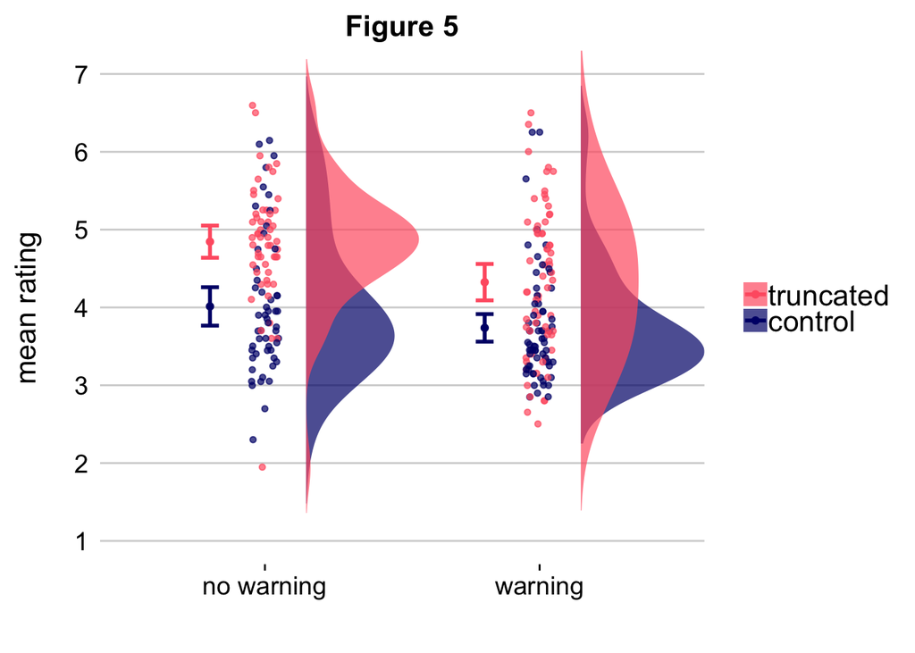

### Truncation effect

| graph_condition | n | mean | sd | median | min | max | range |
| --- | --- | --- | --- | --- | --- | --- | --- |
| control | 119 | 3.860305 | 0.8123498 | 3.70 | 2.30 | 6.25 | 3.95 |
| truncated | 119 | 4.556643 | 0.9024095 | 4.65 | 1.95 | 6.60 | 4.65 |

We first replicated our central effect of interest: the truncation effect. As in Studies 1 and 2, we found that truncated bar graphs exaggerated ratings of differences, compared to control bar graphs: M<sub>control</sub> = 3.86, SD<sub>control</sub> = 0.81); M<sub>truncated</sub> = 4.56, SD<sub>truncated</sub> = 0.9.

```
##
## Cohen's d
##
## d estimate: -0.5157161 (medium)
## 95 percent confidence interval:
##      lower      upper
## -0.7753278 -0.2561044
```

```
##
##  Paired t-test
##
## data:  subject_mean_rating by graph_condition
## t = -10.701, df = 118, p-value < 0.00000000000000022
## alternative hypothesis: true difference in means is not equal to 0
## 95 percent confidence interval:
##  -0.8252022 -0.5674728
## sample estimates:
## mean of the differences
##              -0.6963375
```

This main effect was statistically significant (equal variances not assumed): t(118) = 10.7, p < 4.333554e-19, 95% CI of difference = [0.57, 0.83], d = 0.52.

M<sub>difference</sub> = 0.7.

| direction | n | percentage |
| --- | --- | --- |
| expected | 100 | 84.03361 |
| unexpected | 19 | 15.96639 |

This effect was consistent: 84% (100 of 119) participants showed a truncated effect in the expected direction.

Next, we computed a linear mixed effects model with graph type (0 = control, 1 = truncated) and warning condition (0 = no warning, 1 = warning) as binary fixed factors. Participants’ ratings of the differences depicted by bar graphs was the outcome variable, and participant was included a random effect.There was a statistically significant main effect of graph type and a statistically significant interaction between graph type and warning (Table 2).

```
## Linear mixed model fit by REML. t-tests use Satterthwaite's method [
## lmerModLmerTest]
## Formula:
## rating ~ subject_condition * graph_condition + (1 | participantID)
##    Data: models_df
##
## REML criterion at convergence: 18141.2
##
## Scaled residuals:
##      Min       1Q   Median       3Q      Max
## -2.72161 -0.75299 -0.01808  0.72534  2.66278
##
## Random effects:
##  Groups        Name        Variance Std.Dev.
##  participantID (Intercept) 0.5142   0.7171
##  Residual                  2.4990   1.5808
## Number of obs: 4760, groups:  participantID, 119
##
## Fixed effects:
##                                                     Estimate Std. Error
## (Intercept)                                          4.01321    0.10982
## subject_conditionwarning                            -0.27529    0.14747
## graph_conditiontruncated                             0.83208    0.06867
## subject_conditionwarning:graph_conditiontruncated   -0.24472    0.09220
##                                                           df t value
## (Intercept)                                        143.67881  36.544
## subject_conditionwarning                           143.69808  -1.867
## graph_conditiontruncated                          4639.00003  12.118
## subject_conditionwarning:graph_conditiontruncated 4639.01673  -2.654
##                                                               Pr(>|t|)
## (Intercept)                                       < 0.0000000000000002 ***
## subject_conditionwarning                                       0.06397 .
## graph_conditiontruncated                          < 0.0000000000000002 ***
## subject_conditionwarning:graph_conditiontruncated              0.00798 **
## ---
## Signif. codes:  0 '***' 0.001 '**' 0.01 '*' 0.05 '.' 0.1 ' ' 1
##
## Correlation of Fixed Effects:
##             (Intr) sbjct_ grph_c
## sbjct_cndtn -0.745
## grph_cndtnt -0.313  0.233
## sbjct_cnd:_  0.233 -0.313 -0.745
```

We note that the intercept in this model (4.01) corresponds to ratings for control graphs with no explanatory warning given, acting as a theoretical and practical baseline for ratings on a 7-point scale.

### Table 2

| Row.names | Estimate | 95% CI of Estimate | Std. Error | t value | Pr(>\|t\|) |
| --- | --- | --- | --- | --- | --- |
| (Intercept) | 4.01 | [3.79,4.24] | 0.11 | 36.54 | 0.00000 |
| graph_conditiontruncated | 0.83 | [0.69,0.98] | 0.07 | 12.12 | 0.00000 |
| subject_conditionwarning | -0.28 | [-0.56,0.01] | 0.15 | -1.87 | 0.06397 |
| subject_conditionwarning:graph_conditiontruncated | -0.24 | [-0.43,-0.07] | 0.09 | -2.65 | 0.00798 |

### Effect of an explanatory warning.

Critically, we found that a warning reduces the size of the truncation effect by lowering ratings of truncated graphs selectively. This was revealed by a statistically significant interaction between graph type and warning condition (b = -0.24; Table 2), such that participants who received an explanatory warning judged differences to be smaller for truncated graphs.

We found mixed evidence for a global decrease in judgments following a warning, which would be revealed as a main effect for warning condition. This main effect is not statistically significant in Table 2. However, when we exclude 10 participants who did not initially answer our instructional item correctly (before feedback) from analyses, we do find a statistically significant main effect of Warning Condition, such that participants are globally more conservative for all graph types (b = -0.38, SE = 0.146, t = -2.6, p = 1.036e-02).

#### Table 2 excluding 10 participants who incorrectly answered the instructional item.

| Row.names | Estimate | 95% CI of Estimate | Std. Error | t value | Pr(>\|t\|) |
| --- | --- | --- | --- | --- | --- |
| (Intercept) | 4.013 | [3.804,4.225] | 0.105 | 38.303 | 0.00000 |
| graph_conditiontruncated | 0.832 | [0.69,0.962] | 0.069 | 12.049 | 0.00000 |
| subject_conditionwarning | -0.380 | [-0.669,-0.1] | 0.146 | -2.600 | 0.01036 |
| subject_conditionwarning:graph_conditiontruncated | -0.292 | [-0.484,-0.105] | 0.096 | -3.026 | 0.00249 |

Overall, we find mixed evidence that our explanatory warning decreases graph ratings for all judgments of differences, and strong evidence that an explanatory warning selectively decreases graph ratings for truncated graphs.

## Supplemental Information

### Methods (Supplemental Information)

#### Participants (Supplemental Information)

118 participants reported English as their first language, and 1 reported Vietnamese as their first language.

| dem_ed | n | percentage |
| --- | --- | --- |
| 2 | 11 | 9.2436975 |
| 3 | 24 | 20.1680672 |
| 4 | 1 | 0.8403361 |
| 5 | 9 | 7.5630252 |
| 6 | 58 | 48.7394958 |
| 7 | 3 | 2.5210084 |
| 8 | 13 | 10.9243697 |

70% of participants reported having at least a Bachelor’s degree.

| mean_duration | sd_duration | median_duration | min_duration | max_duration | range_duration |
| --- | --- | --- | --- | --- | --- |
| 21.35392 | 23.81287 | 14.55 | 3.583333 | 219.5167 | 215.9333 |

The experiment took participants an average of M<sub>duration</sub> = 21.35 minutes, (SD<sub>duration</sub> = 23.81 minutes).

### Results (Supplemental Information)

#### Graph Literacy (Supplemental Information)

##### Main Effect

```
##
## Call:
## lm(formula = difference ~ graphliteracy_sum_rating, data = models_difference_df)
##
## Residuals:
##      Min       1Q   Median       3Q      Max
## -1.70985 -0.50410  0.03274  0.50367  1.66792
##
## Coefficients:
##                          Estimate Std. Error t value Pr(>|t|)
## (Intercept)              0.193155   0.347786   0.555    0.580
## graphliteracy_sum_rating 0.011482   0.007797   1.473    0.144
##
## Residual standard error: 0.7064 on 117 degrees of freedom
## Multiple R-squared:  0.0182, Adjusted R-squared:  0.009805
## F-statistic: 2.168 on 1 and 117 DF,  p-value: 0.1436
```

Truncation effect is mean rating for truncated graphs - mean rating for control graphs.

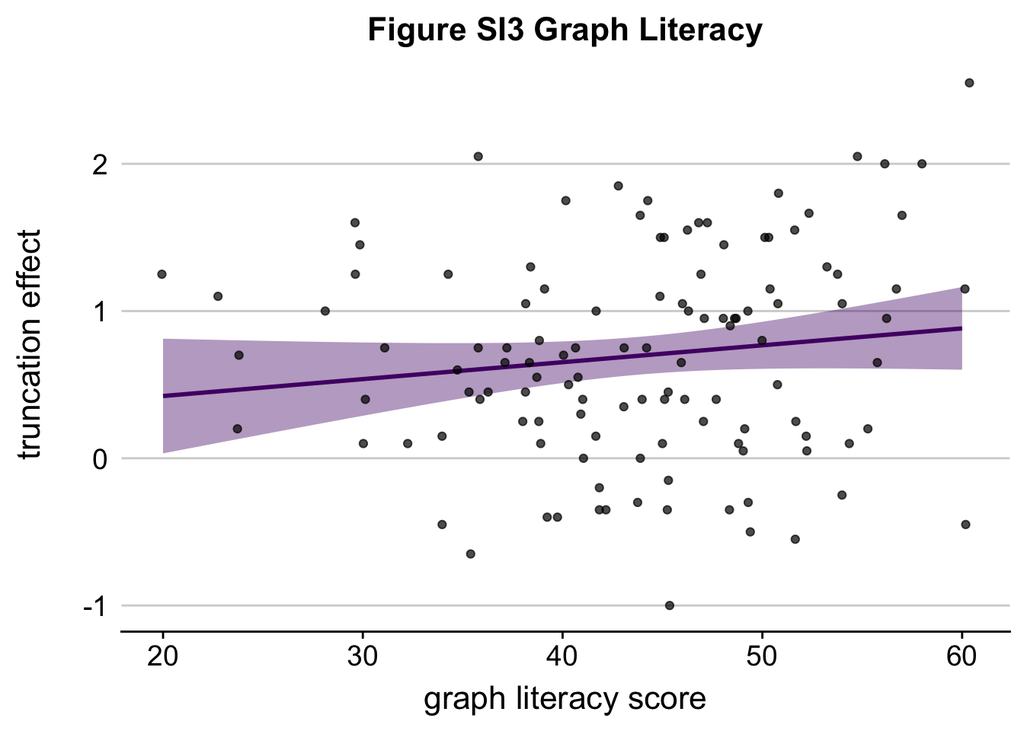

##### Including item as a random effect

Estimating 95% CIs for betas below This estimation fails to converge, so we reverted back to including only participant as a random effect. This does not alter the conclusions from this model.

##### Interaction with warning

```
##
## Call:
## lm(formula = difference ~ graphliteracy_sum_rating * subject_condition,
##     data = models_difference_df)
##
## Residuals:
##      Min       1Q   Median       3Q      Max
## -1.61082 -0.45415  0.02406  0.45791  1.70430
##
## Coefficients:
##                                                   Estimate Std. Error
## (Intercept)                                        0.68743    0.55869
## graphliteracy_sum_rating                           0.00327    0.01244
## subject_conditionwarning                          -0.78125    0.71026
## graphliteracy_sum_rating:subject_conditionwarning  0.01239    0.01589
##                                                   t value Pr(>|t|)
## (Intercept)                                         1.230    0.221
## graphliteracy_sum_rating                            0.263    0.793
## subject_conditionwarning                           -1.100    0.274
## graphliteracy_sum_rating:subject_conditionwarning   0.780    0.437
##
## Residual standard error: 0.7005 on 115 degrees of freedom
## Multiple R-squared:  0.05089,    Adjusted R-squared:  0.02613
## F-statistic: 2.055 on 3 and 115 DF,  p-value: 0.11
```

Truncation effect is mean rating for truncated graphs - mean rating for control graphs.

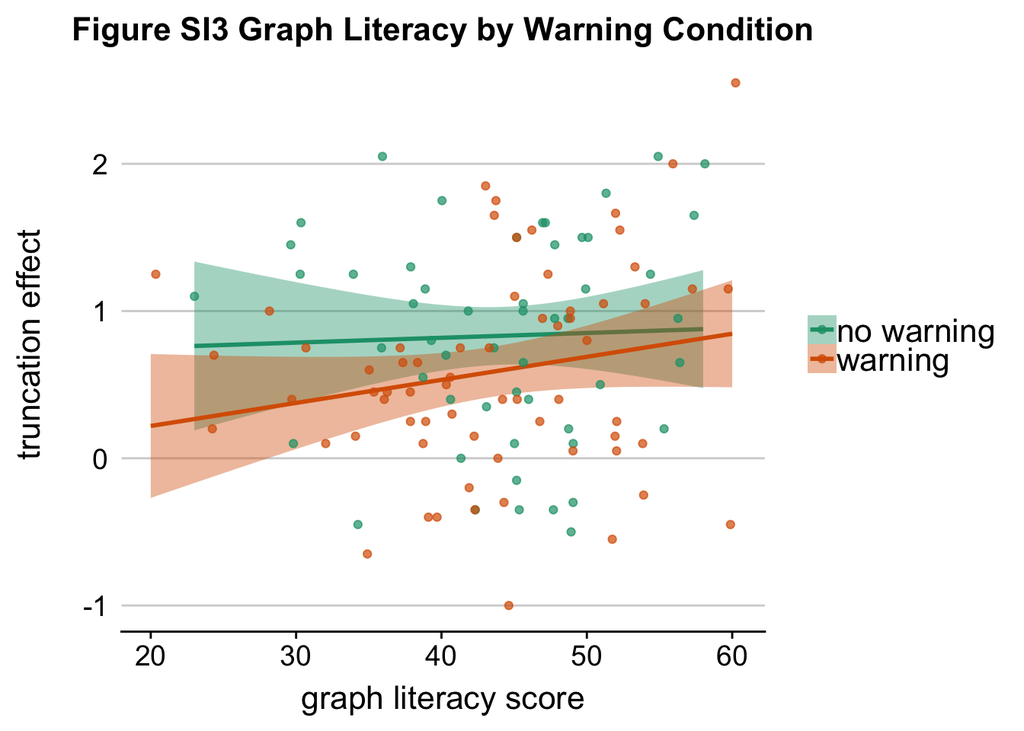

#### Education (Supplemental Information)

##### Main Effect

```
##
## Call:
## lm(formula = difference ~ dem_ed, data = models_difference_df)
##
## Residuals:
##     Min      1Q  Median      3Q     Max
## -1.7707 -0.5182 -0.0207  0.4805  1.8818
##
## Coefficients:
##             Estimate Std. Error t value  Pr(>|t|)
## (Intercept)  0.87320    0.19969   4.373 0.0000268 ***
## dem_ed      -0.03417    0.03647  -0.937     0.351
## ---
## Signif. codes:  0 '***' 0.001 '**' 0.01 '*' 0.05 '.' 0.1 ' ' 1
##
## Residual standard error: 0.7102 on 117 degrees of freedom
## Multiple R-squared:  0.007446,   Adjusted R-squared:  -0.001038
## F-statistic: 0.8777 on 1 and 117 DF,  p-value: 0.3508
```

Truncation effect is mean rating for truncated graphs - mean rating for control graphs.

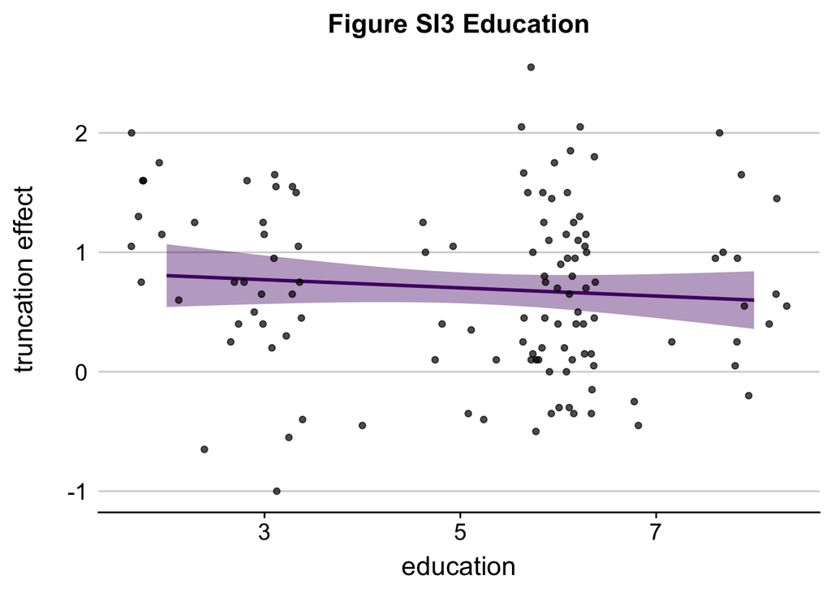

##### Interaction with warning

```
##
## Call:
## lm(formula = difference ~ dem_ed * subject_condition, data = models_difference_df)
##
## Residuals:
##      Min       1Q   Median       3Q      Max
## -1.59651 -0.48546 -0.00094  0.47816  1.96675
##
## Coefficients:
##                                 Estimate Std. Error t value  Pr(>|t|)
## (Intercept)                      1.26029    0.30176   4.176 0.0000579 ***
## dem_ed                          -0.08077    0.05394  -1.497     0.137
## subject_conditionwarning        -0.65051    0.39911  -1.630     0.106
## dem_ed:subject_conditionwarning  0.07634    0.07258   1.052     0.295
## ---
## Signif. codes:  0 '***' 0.001 '**' 0.01 '*' 0.05 '.' 0.1 ' ' 1
##
## Residual standard error: 0.7015 on 115 degrees of freedom
## Multiple R-squared:  0.04824,    Adjusted R-squared:  0.02341
## F-statistic: 1.943 on 3 and 115 DF,  p-value: 0.1266
```

Truncation effect is mean rating for truncated graphs - mean rating for control graphs.

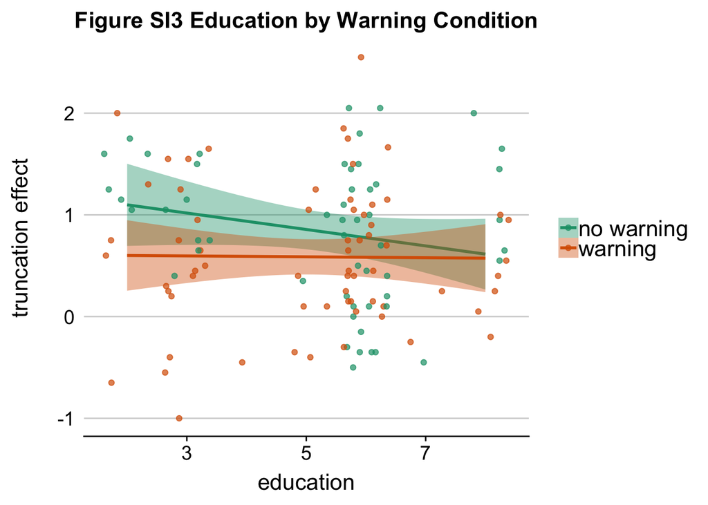

##### Education and graph literacy

```
##
## Call:
## lm(formula = graphliteracy_sum_rating ~ dem_ed, data = models_difference_df)
##
## Residuals:
##     Min      1Q  Median      3Q     Max
## -21.943  -4.807   0.465   5.465  17.193
##
## Coefficients:
##             Estimate Std. Error t value            Pr(>|t|)
## (Intercept)  39.3511     2.3138  17.007 <0.0000000000000002 ***
## dem_ed        0.8640     0.4226   2.045              0.0431 *
## ---
## Signif. codes:  0 '***' 0.001 '**' 0.01 '*' 0.05 '.' 0.1 ' ' 1
##
## Residual standard error: 8.23 on 117 degrees of freedom
## Multiple R-squared:  0.0345, Adjusted R-squared:  0.02625
## F-statistic:  4.18 on 1 and 117 DF,  p-value: 0.04314
```

#### Age (Supplemental Information)

##### Main Effect

```
##
## Call:
## lm(formula = difference ~ dem_age, data = models_difference_df)
##
## Residuals:
##      Min       1Q   Median       3Q      Max
## -1.68902 -0.52278 -0.00887  0.50047  1.86332
##
## Coefficients:
##             Estimate Std. Error t value Pr(>|t|)
## (Intercept) 0.658650   0.278829   2.362   0.0198 *
## dem_age     0.001168   0.008400   0.139   0.8897
## ---
## Signif. codes:  0 '***' 0.001 '**' 0.01 '*' 0.05 '.' 0.1 ' ' 1
##
## Residual standard error: 0.7128 on 117 degrees of freedom
## Multiple R-squared:  0.0001652,  Adjusted R-squared:  -0.00838
## F-statistic: 0.01933 on 1 and 117 DF,  p-value: 0.8897
```

Truncation effect is mean rating for truncated graphs - mean rating for control graphs.

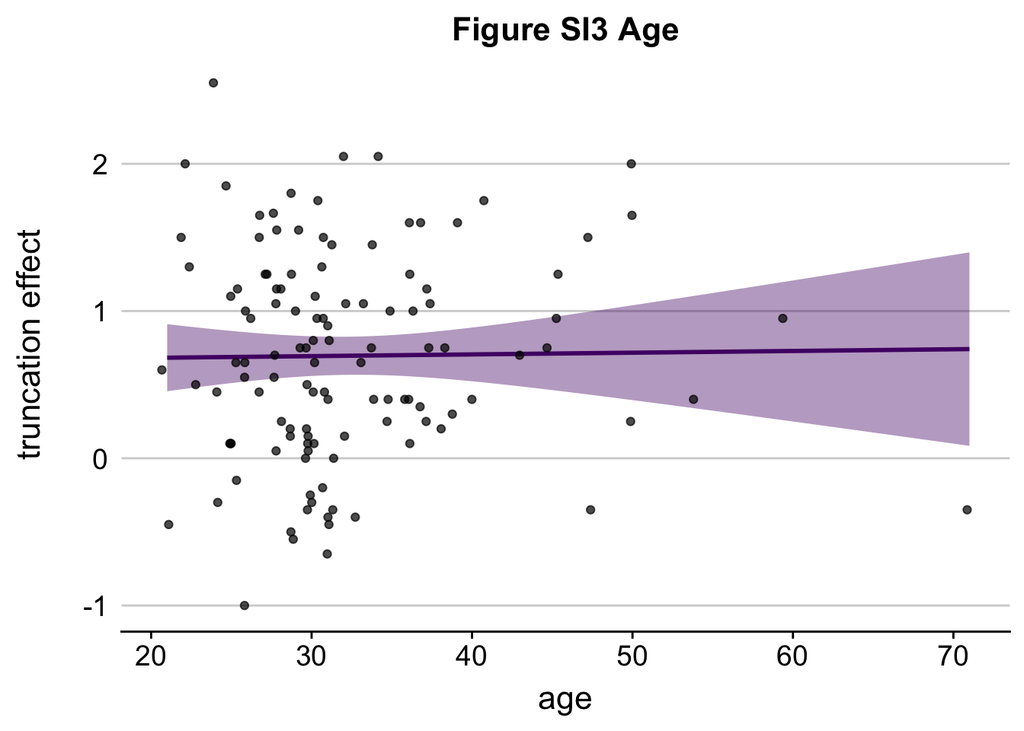

##### Interaction with warning

```
##
## Call:
## lm(formula = difference ~ dem_age * subject_condition, data = models_difference_df)
##
## Residuals:
##      Min       1Q   Median       3Q      Max
## -1.66299 -0.47601 -0.02682  0.49177  1.85327
##
## Coefficients:
##                                   Estimate Std. Error t value Pr(>|t|)
## (Intercept)                       0.728115   0.368018   1.978   0.0503 .
## dem_age                           0.003014   0.010295   0.293   0.7702
## subject_conditionwarning          0.373483   0.606912   0.615   0.5395
## dem_age:subject_conditionwarning -0.019884   0.018668  -1.065   0.2891
## ---
## Signif. codes:  0 '***' 0.001 '**' 0.01 '*' 0.05 '.' 0.1 ' ' 1
##
## Residual standard error: 0.7045 on 115 degrees of freedom
## Multiple R-squared:  0.04012,    Adjusted R-squared:  0.01508
## F-statistic: 1.602 on 3 and 115 DF,  p-value: 0.1927
```

Truncation effect is mean rating for truncated graphs - mean rating for control graphs.

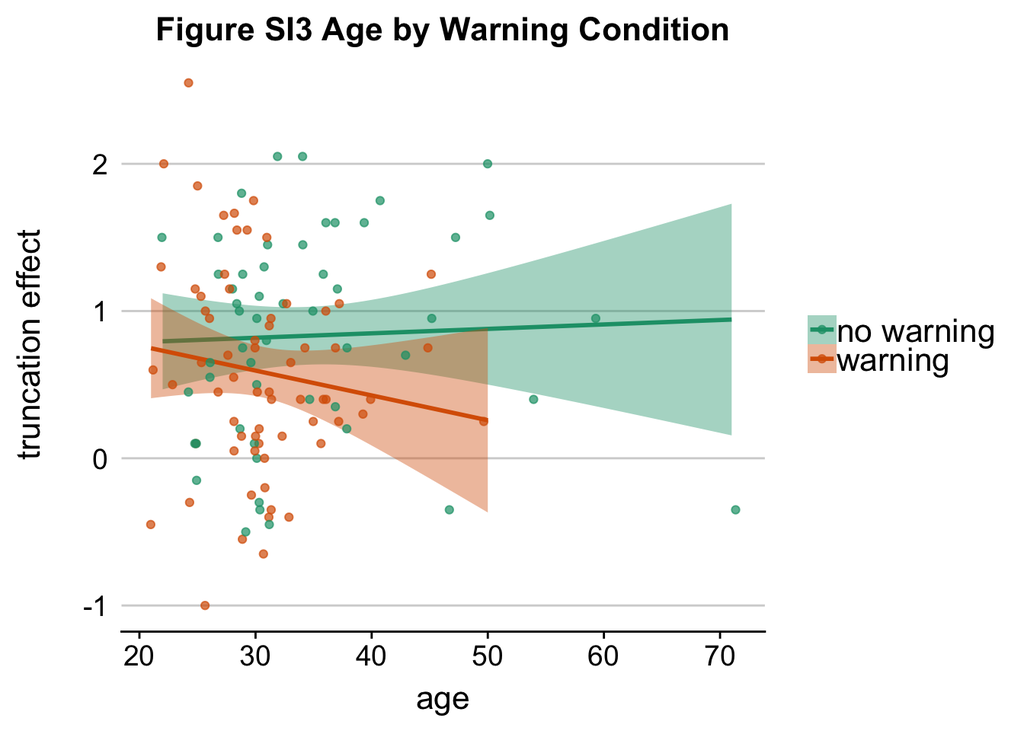

#### Item Analysis (Supplemental Information)

##### Main Effect of Warning

Here we summarise the data for each item. This is helpful to identify if the effect is driven by a few graphs or if it is seen across all graphs in the materials.

| question | no warning | warning | diff |
| --- | --- | --- | --- |
| 1 | 4.150943 | 3.484848 | 0.666094911 |
| 2 | 4.461538 | 4.469697 | -0.008158508 |
| 3 | 3.188679 | 2.742424 | 0.446255003 |
| 4 | 5.000000 | 4.803030 | 0.196969697 |
| 5 | 5.037736 | 4.833333 | 0.204402516 |
| 6 | 3.773585 | 3.681818 | 0.091766724 |
| 7 | 5.377358 | 4.469697 | 0.907661521 |
| 8 | 3.555556 | 3.439394 | 0.116161616 |
| 9 | 4.660377 | 3.984848 | 0.675528874 |
| 10 | 2.867925 | 2.651515 | 0.216409377 |

[output cut: 30 more lines]

| n | mean | sd | median | min | max | range |
| --- | --- | --- | --- | --- | --- | --- |
| 40 | 0.3975075 | 0.2630285 | 0.3603488 | 0.008158508 | 0.9076615 | 0.899503 |

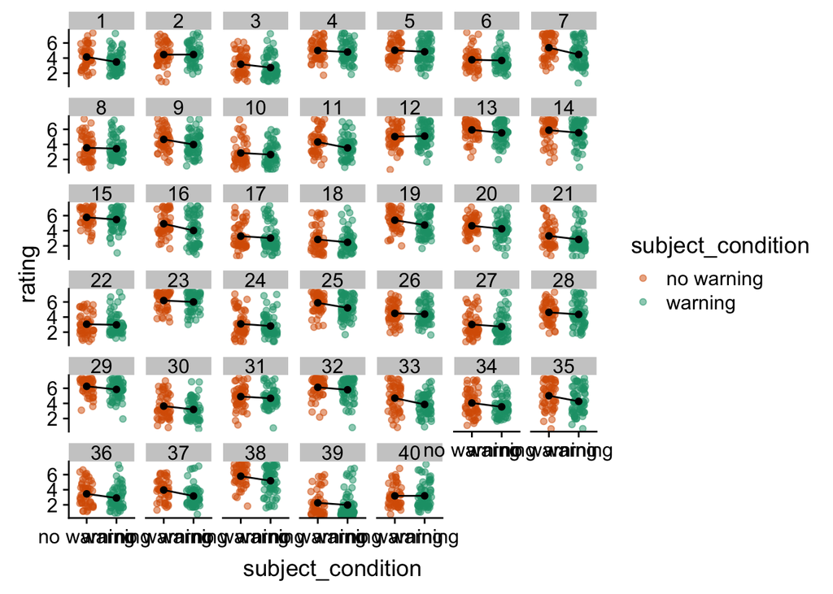

| question | no warning | warning | diff |
| --- | --- | --- | --- |
| 2 | 4.461538 | 4.469697 | -0.008158508 |
| 12 | 5.037736 | 5.106061 | -0.068324757 |
| 40 | 3.188679 | 3.196970 | -0.008290452 |

The effect of warning was observed for all graphs except graph 2, 12 and 40. On average, the 7-point ratings were 0.4 (SD = 0.26) higher when graphs were seen in the no warning condition than when they were seen in the warning condition. The maximum average absolute difference between the no warning and the warningconditions was for graph 7 M = 0.91. The minimum average absolute difference was for graph 2 where M = 0.01.

##### Warning interaction with graph type

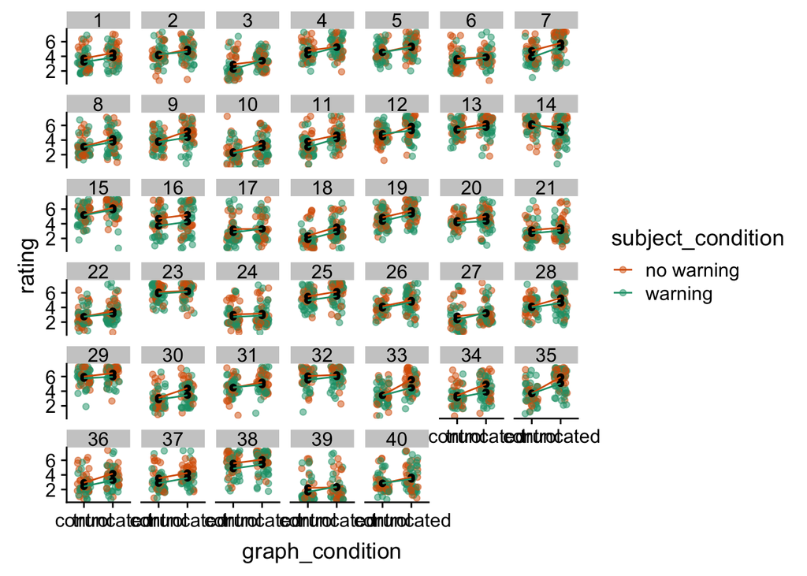

#### Timing (Supplemental Information)

Timing information is in seconds.

You can choose to trim or not timing data. By default any timing that is 2 standard deviations away from the mean (for each participant for each condition) is trimmed.

For this report, any timing that is 2 standard deviations away from the mean (for each participant for each condition) WAS NOT trimmed. If you want to see results when participants who got the exercise wrong are excluded/included, you can go to the section called Exclusions (at the top of this file) and change **Trimming <- FALSE**

| subject_condition | graph_condition | n | mean | sd | median | min | max | range |
| --- | --- | --- | --- | --- | --- | --- | --- | --- |
| no warning | control | 53 | 12.87355 | 9.354404 | 10.05555 | 0.95750 | 51.49645 | 50.53895 |
| no warning | truncated | 53 | 15.20035 | 20.856401 | 10.26970 | 0.70195 | 126.65020 | 125.94825 |
| warning | control | 66 | 19.71294 | 22.470937 | 13.62215 | 1.32770 | 132.06520 | 130.73750 |
| warning | truncated | 66 | 16.97072 | 17.432665 | 12.65067 | 0.73615 | 109.31800 | 108.58185 |

| graph_condition | n | mean | sd | median | min | max | range |
| --- | --- | --- | --- | --- | --- | --- | --- |
| control | 119 | 16.66682 | 18.12073 | 11.77895 | 0.95750 | 132.0652 | 131.1077 |
| truncated | 119 | 16.18223 | 18.97030 | 10.94875 | 0.70195 | 126.6502 | 125.9483 |

| subject_condition | n | mean | sd | median | min | max | range |
| --- | --- | --- | --- | --- | --- | --- | --- |
| no warning | 53 | 14.03695 | 16.12841 | 10.20297 | 0.70195 | 126.6502 | 125.9483 |
| warning | 66 | 18.34183 | 20.08053 | 12.82018 | 0.73615 | 132.0652 | 131.3290 |